# Notebook

```python
from __future__ import division, print_function
from brian import *
from tools.plot import quicktitle
```

```python
%matplotlib inline
```

## Load the trajectory data

```python
import os
datadir = '/Users/joe/source/phase_model/data'
posfile = os.path.join(datadir, 'pos.npy')
pos = np.load(posfile)
x_pos, y_pos = pos[1:3] * cm
t_pos = (pos[0] - pos[0][0]) * second
```

## Model parameters

Population level parameters and values:

```python
R_arena = 40.0 * cm
D_arena = 2 * R_arena

N_BVC = 36
BVC_sigma = (10 * cm, 25 * cm)
BVC_min = 0.1

N_LCO = 8
chi = 0.6 * mA
C_in = 4
```

## Helper functions

This function sets an axis for the arena and draws the cylinder edge.

```python
def set_arena(ax=None):
    if ax is None:
        ax = gca()
    ax.add_artist(mpl.patches.Circle((0,0), radius=R_arena / cm, fill=False, ec='0.3',
                                     lw=2, ls='dashed', zorder=-1))
    ax.axis(array([-1,1,-1,1]) * 1.2 * R_arena / cm)
    return ax
```

This function uniformly samples a circular disc for spatial phase offsets.

```python
def randc(N, radius):
    t = 2 * pi * rand(N)
    r = rand(N) + rand(N)
    r[r > 1] = 2 - r[r > 1]
    r *= radius
    return np.c_[r * cos(t), r * sin(t)].T
```

## Neuron groups

These are the equations for the BVC group of neurons:

```python
bvc_eqs = """
    f = 0.5 + tanh(2 * (D - (1 - BVC_min) * D_arena + sigma) / sigma) / 2 : 1
    D = sqrt((X - Xp)**2 + (Y - Yp)**2) : cm
    sigma : cm
    Xp : cm # x-dimension spatial offset
    Yp : cm # y-dimension spatial offset
    X : cm
    Y : cm
"""
BVC = NeuronGroup(N_BVC, model=bvc_eqs)

BVC.Xp, BVC.Yp = randc(N_BVC, R_arena)
BVC.sigma = BVC_sigma[0] + diff(BVC_sigma) * rand(N_BVC)
```

These are the equations for the LCO group of neurons:

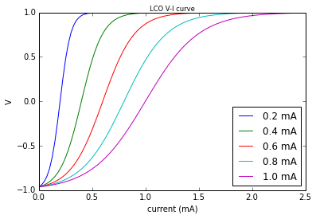

```python
def v_LCO(I, thresh=0.5 * mA):
    return tanh(2 * (I - thresh) / thresh)

# Plot v_LCO(d) for different slope values
current = linspace(0,2.5,100) * mA
for t in array([0.2,0.4,0.6,0.8,1.0]) * mA:
    plt.plot(current / mA, v_LCO(current, thresh=t), label='%.1f mA' % (t / mA))
plt.xlabel('current (mA)')
plt.ylabel('V')
plt.legend(loc='lower right');
quicktitle(gca(), 'LCO V-I curve');
```

I can't actually figure out how to create a firing-rate network using this simulator platform, since it seems to be based entirely on spikes to get postsynaptic changes. So it looks like I will have to compute the LCO population activity *post hoc*.

First, create the BCV -> LCO feedforward weight matrix that will be used later on (along with the activation function above):

```python
W = zeros((N_BVC, N_LCO), 'd')
for j in xrange(N_LCO):
    con = permutation(N_BVC)[:C_in]
    W[con,j] = 1.0
print('C_in = ', W.sum(axis=0), '(should be %d)' % C_in)
```

```
C_in =  [ 4.  4.  4.  4.  4.  4.  4.  4.] (should be 4)
```

### Model parameters

Plot the BVC parameters.

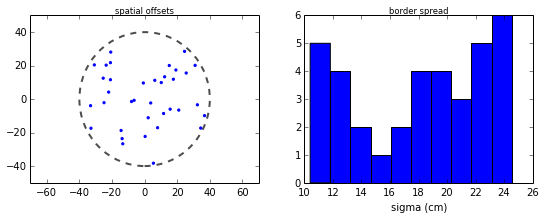

```python
from tools.plot import quicktitle
f, ax = subplots(1, 2, figsize=(9,3))
ax1, ax2 = ax

ax1.scatter(BVC.Xp / cm, BVC.Yp / cm, marker='.', color='b')
set_arena(ax1)
ax1.axis([-70,70,-50,50])
quicktitle(ax1, 'spatial offsets')

ax2.hist(BVC.sigma / cm)
ax2.set_xlabel('sigma (cm)')
quicktitle(ax2, 'border spread');
```

## Trajectory inputs and monitors

Create TimedArrays for the `(x,y)` trajectory data channels and then set up monitors for the model variables.

```python
# Add the timed trajectory data into the BVC population
BVC.X = TimedArray(x_pos, t_pos)
BVC.Y = TimedArray(y_pos, t_pos)
start_t = t_pos[0] * second

# Create the state monitors
f_ = StateMonitor(BVC, 'f', record=True)
D_ = StateMonitor(BVC, 'D', record=True)
X_ = StateMonitor(BVC, 'X', record=True)
Y_ = StateMonitor(BVC, 'Y', record=True)
```

## Reset the clock and run the simulation

Update the default simulation clock to concur with the timing of the trajectory segment that we're using.

```python
reinit_default_clock()
defaultclock.dt = 100 * ms
defaultclock.start = start_t

run(180 * second)
```

### Plotting some example BVC maps

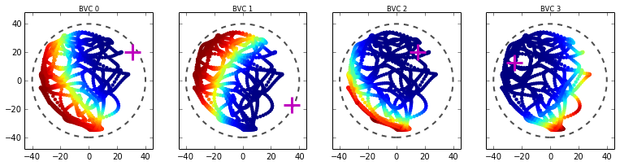

```python
f, ax = subplots(1, 4, sharey=True, sharex=True, figsize=(13,3))

def plot_phase_trajectory(i, ax):
    ax.plot(BVC.Xp[i] / cm, BVC.Yp[i] / cm, 'm+', ms=20, mew=3)
    ax.scatter(X_[0] / cm, Y_[0] / cm, c=f_[i], cmap='jet', linewidths=0)
    ax.axis('equal')
    set_arena(ax)

for i in xrange(4):
    plot_phase_trajectory(i, ax[i])
    quicktitle(ax[i], 'BVC %d' % i)
```

### Post-hoc computation of LCO firing rate and phase

```python
I = dot(f_[:].T, W).T
V = tanh(2 * (I - (chi / mA)) / (chi / mA))
f_LCO = clip(V, 0, 1)
Theta = arccos(V)
```

Example activation traces from an LCO unit:

```
I ~ 0.00136568633913 to 2.21044462145
V ~ -0.963704541756 to 0.999956518371
f ~ 0.0 to 0.999956518371
```

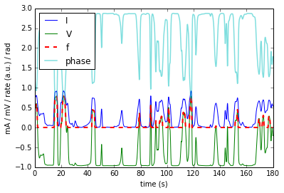

```python
plot(X_.times, I[0], label='I')
plot(X_.times, V[0], label='V')
plot(X_.times, f_LCO[0], '--', lw=2, label='f')
plot(X_.times, Theta[0], lw=1.5, alpha=0.5, label='phase')
xlabel('time (s)')
ylabel('mA / mV / rate (a.u.) / rad')
legend(loc='upper left')

print('I ~', I.min(), 'to', I.max())
print('V ~', V.min(), 'to', V.max())
print('f ~', f_LCO.min(), 'to', f_LCO.max())
```

##### This is just here for reference; implemented post-hoc above:

lco_eqs = """ Theta = arccos(V) : radian f = clip(V, 0, 1) : 1 V = tanh(2 * (I - chi) / chi) : 1 I : 1 """ LCO = NeuronGroup(N_LCO, model=lco_eqs)

### Plot LCO phase and firing rate trajectory maps

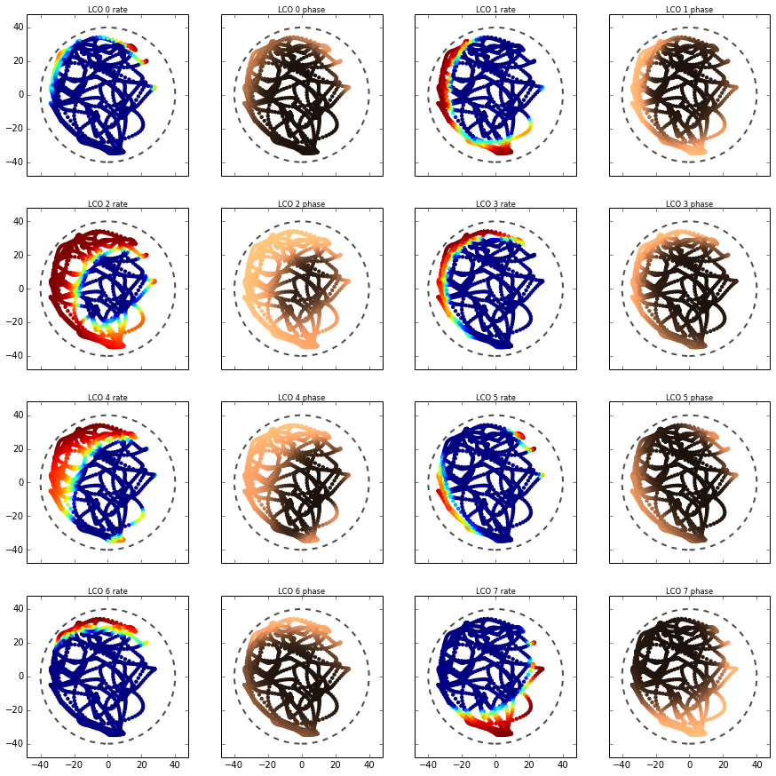

```python
N_plots = 2 * N_LCO

from tools.images import tiling_dims
r, c = tiling_dims(N_plots)

f, ax = subplots(r, c, sharey=True, sharex=True, figsize=(15,15))
ax = ax.flatten()

def plot_phase_trajectory(cdata, ax, cmap='jet', **kwds):
    ax.scatter(X_[0] / cm, Y_[0] / cm, c=cdata, cmap=cmap, linewidths=0, **kwds)
    ax.axis('equal')
    set_arena(ax)

j = 0
for i in xrange(N_LCO):
    for ttl, val, cmap in [('rate', f_LCO, 'jet'), ('phase', Theta, 'copper_r')]:
        scatter_kwds = {}
        if ttl == 'phase':
            scatter_kwds.update(vmin=0, vmax=pi)
        plot_phase_trajectory(val[i], ax[j], cmap, **scatter_kwds)
        quicktitle(ax[j], 'LCO %d %s' % (i, ttl))
        j += 1
```